# Avaliação 1

Econometria Aplicada à Finanças

Autor

Prof. Dr. Washington S. da Silva

Data de Publicação

1 de outubro de 2024

## Questão 1 - Questões Conceituais

**a.** Ao longo da disciplina, usaremos o estimador de MQO $\hat{\beta}$ para estimar $\beta$. Explique, de forma intuitiva, o que significa $\hat{\beta}$ ser viesado para $\beta$.

**b.** Qual é a definição formal (matemática) de **viés**?

**c.** Por que nos importamos se o estimador de MQO (ou qualquer estimador) é **viesado**?

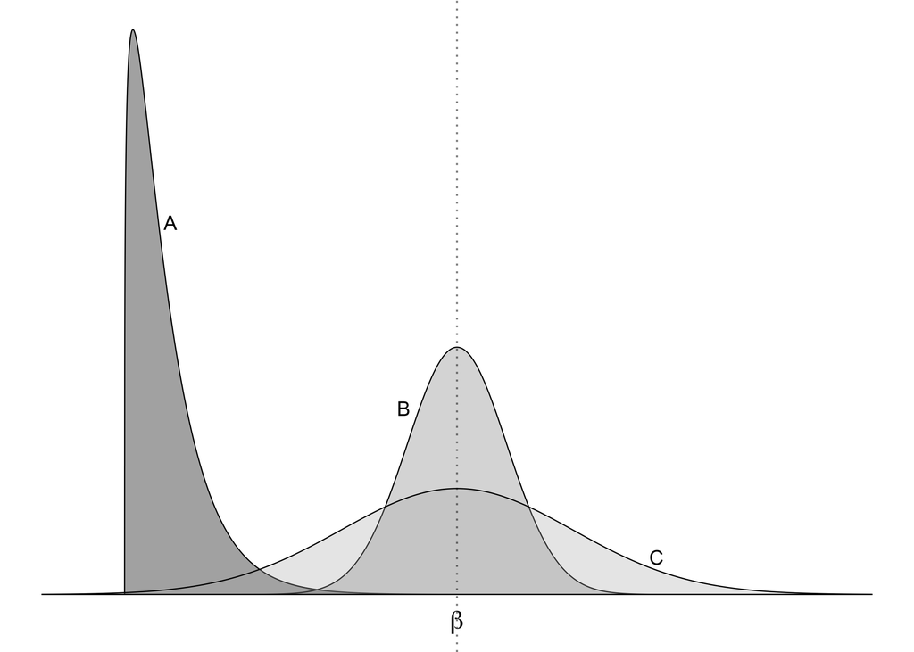

Figura 1: Distribuição Amostral de 3 Estimadores (A, B e C) do parâmetro populacional$ $\beta$.

A Fig. 1 mostra as distribuições de três estimadores (A, B e C), cada um dos quais estima o parâmetro desconhecido $\beta$, sendo que $E[A]= \beta - 3$, $E[B]= \beta$, $E[C]= \beta$.

**d.** Quais dos estimadores na Fig. 1 (acima) são não viesados? *Dica:* Pode haver mais de um.

**e.** Qual dos estimadores na Fig. 1 (acima) possui a menor variância?

**f.** Qual dos estimadores na Figura 1 Fig. 1 é o **melhor** estimador não viesado (com menor variância)?

**g.** Suponha que queremos estimar o efeito dos gastos sobre publicidade sobre as vendas. Explique o que *viés* significaria nesse contexto.

**h.** O que significa o termo “erro padrão”?

**i.** **Verdadeiro/Falso**: A ausência de viés é uma propriedade para amostras de tamanho finito, enquanto a consistência refere-se a um estimador conforme o tamanho da amostra se aproxima do infinito. Explique sua opção.

**j.** O que significa que um estimador seja **consistente**?

**l.** Qual dos seguintes dois estimadores você escolheria? Explique seu raciocínio.

- Estimador **A** é não viesado e inconsistente.
- Estimador **B** é viesado e consistente.

**m.** Qual é a definição de heterocedasticidade?

**n.** Por que estamos preocupados com a heterocedasticidade?

**o.** Fazer o gráfico de dispersão de $y$ contra $x$ nos diz algo sobre a heterocedasticidade?

**p.** Fazer o gráfico de dispersão de $e$ contra $x$ nos diz algo sobre a heterocedasticidade?

**q.** Como não podemos observar os $u_i$ (erros populacionais), o que usamos para *aprender* sobre a heterocedasticidade?

**r.** Qual teste você recomenda para testar a heterocedasticidade? Por quê?

## Questão 2 - Análise

Revisando ferramentas básicas de análise em econometria.

**Bertrand e Mullainathan (2004)**

Os dados utilizados neste questão vêm do artigo de Bertrand e Mullainathan (2004), publicado na *American Economic Review* (AER) em 2004. O arquivo de dados disponibilizado nas contêm um subconjunto das variáveis do artigo original.

Em seu artigo (muito influente), Bertrand e Mullainathan utilizaram um experimento engenhoso para estudar os efeitos da raça nas decisões do mercado de trabalho, enviando currículos falsos para anúncios de emprego. Para isolar o efeito da raça nas decisões de emprego, Bertrand e Mullainathan aleatorizam se o currículo apresenta um nome tipicamente afro-americano ou um nome tipicamente branco.

- Descrição do Experimento:

O experimento delineado por Bertrand e Mullainathan (2004) foi projetado para investigar a discriminação racial no mercado de trabalho dos Estados Unidos. Ele utilizou uma metodologia engenhosa de envio de currículos fictícios para medir o impacto de nomes associados a diferentes raças na probabilidade de receber um retorno de entrevista.

1. **Objetivo**: O estudo tinha como objetivo investigar se candidatos com nomes que soam como “brancos” ou “afro-americanos” são tratados de maneira diferente ao procurar empregos.
2. **Envio de Currículos**: Os pesquisadores responderam a mais de 1.300 anúncios de emprego publicados em jornais de Boston e Chicago. Foram enviados quase 5.000 currículos fictícios, distribuídos entre várias categorias de emprego, como vendas, suporte administrativo e atendimento ao cliente.
3. **Manipulação dos Nomes**: Os currículos foram divididos aleatoriamente em dois grupos. Um grupo foi designado com nomes “brancos” (como Emily Walsh ou Greg Baker) e o outro com nomes “afro-americanos” (como Lakisha Washington ou Jamal Jones). Essa manipulação permitiu que os autores isolassem o impacto da percepção racial com base apenas nos nomes.
4. **Qualidade dos Currículos**: Além de manipular os nomes, os currículos também variavam em termos de qualidade. Currículos de alta qualidade incluíam mais experiência de trabalho, menos lacunas no histórico de emprego e habilidades adicionais, como certificações ou conhecimentos em idiomas estrangeiros. Currículos de menor qualidade apresentavam menos qualificações.
5. **Medida de Sucesso**: O principal resultado medido foi a taxa de retorno de entrevistas (*callbacks*), ou seja, quantos empregadores responderam positivamente aos currículos, convidando o candidato para uma entrevista.
- Resultados Principais:
1. **Disparidade Racial**: Os currículos com nomes “brancos” receberam 50% mais convites para entrevistas do que aqueles com nomes “afro-americanos”. Especificamente, enquanto um candidato com nome “branco” precisava enviar cerca de 10 currículos para receber um retorno, um candidato com nome “afro-americano” precisava enviar cerca de 15.
2. **Efeito da Qualidade do Currículo**: Os currículos de alta qualidade aumentaram significativamente a taxa de retorno para candidatos com nomes “brancos”, mas tiveram um efeito muito menor para candidatos com nomes “afro-americanos”. Ou seja, mesmo quando o currículo era de alta qualidade, candidatos com nomes “afro-americanos” não se beneficiavam tanto quanto os candidatos com nomes “brancos”.
3. **Uniformidade do Efeito**: A diferença no tratamento com base na raça foi observada de maneira consistente em diferentes setores, indústrias e tamanhos de empresa. Mesmo em empresas que se apresentavam como “Empregadores de Oportunidades Iguais”, a discriminação racial ainda era evidente.

**a.** Baixe o arquivo de dados `bertrand2004.csv`. Coloque o arquivo na subpasta `data/raw` do seu projeto `ecnt2024_mpa`. Importe este arquivo utilizando o pacote `here` e a função apropiada do pacote `readr`. Qual a dimensão dos dados importados?

**Nota:** Cada linha neste conjunto de dados representa um currículo diferente enviado para uma vaga de emprego. A Tab. 1 apresenta um dicionário dados. O objeto `dados_bertrand` é uma `tibble` com 4870 linhas (observações) e 12 colunas (variáveis).

**b.** Quais são os dois primeiros *primeiros nomes* no conjunto de dados (variável `first_name`)?

**c.** Qual é a porcentagem de currículos que receberam um retorno (variável `i_callback`)?

**Dica:** A média de uma variável binária (isto é, `mean(variavel_binaria)`) fornece a porcentagem de vezes que a variável é igual a um. *Por exemplo*, `mean(df$female)` nos daria a porcentagem de indivíduos do sexo feminino em nosso conjunto de dados `df`.

**d.** Calcule a porcentagem de retornos (*isto é*, a média de `i_callback`) para cada grupo racial (`race`). Parece que os empregadores consideraram a raça do candidato ao fazer os retornos? Explique.

**Dica:** `filter(df, race == "b")` selecionará todas as observações (do conjunto de dados `df`) onde a variável `race` assume o valor `"b"`. Da mesma forma, `filter(your_df, race == "b")$i_callback` fornecerá os valores de `i_callback` para observações cujo valor de `race` é `"b"`.

**e.** Qual é a diferença na taxa média de retorno entre os grupos?

**f.** Com base na diferença nas porcentagens que observamos no item **d**, podemos concluir que os empregadores consideram a raça nas decisões de contratação? **Explique sua resposta.**

**g.** Sem estimar uma regressão, realize um teste estatístico para a diferença nas taxas médias de retorno entre os dois grupos (*isto é*, teste se a proporção de retornos é igual para os dois grupos).

**Dica:** Intervalo de confiança e teste para Diferença entre proporções.

**h.** Agora faça a regressão de `i_callback` (se o currículo gerou um retorno) contra `i_black` (se o nome do currículo indicava um candidato negro). Reporte a estimativa do parâmetro de `i_black`. Ele corresponde à diferença que você encontrou em **e**?

**i.** Realize um teste *t* para o coeficiente de `i_black` na regressão feita no item **h**. Escreva suas hipóteses (tanto $H_0$ quanto $H_A$), a estatística do teste, o valor-p, o resultado do teste (isto é, rejeitar ou não rejeitar $H_0$), e sua conclusão.

**j.** Agora faça a regressão de `i_callback` (se o currículo gerou um retorno) contra `i_black`, `n_expr` (anos de experiência) e a interação entre `i_black` e `n_expr`. Interprete as estimativas dos coeficientes (tanto o significado dos coeficientes quanto se eles são estatisticamente significativos).

**Dica:** Em R, `lm(y ~ x1 + x2 + x1:x2, data = seu_df)` realiza a regressão entre `y` e `x1`, `x2` e a interação entre `x1` e `x2`.

## Questão 3 - Pensando sobre Causalidade

O projeto de Bertrand e Mullainathan (2004) exigiu uma boa quantidade de tempo e esforço — encontrar anúncios de emprego, gerar currículos falsos, responder aos anúncios, *etc.* Teria sido muito mais rápido/barato/fácil simplesmente obter dados de candidatos reais — se eles receberam retornos e suas raças. Então, por que eles não escolheram a rota mais fácil, barata e rápida?

**a.** Defina viés de variável omitida.

**b.** A questão central do projeto é “*Os empregadores retornam a aplicação de currículos para indivíduos em diferentes taxas com base em sua raça (ou gênero)?*”

Se coletássemos dados sobre retornos da aplicação de currículis e raça e, em seguida, realizássemos uma regressão de *Retorno* contra *Raça*, provavelmente obteríamos estimativas viesadas devido ao viés de variável omitida.

Explique por que isso acontece e forneça um exemplo de uma variável omitida nessa situação.

**c.** O objetivo dos experimentos é evitar o viés de variável omitida. Explique como a aleatorização da raça nesses currículos (falsos) evitou as preocupações com o viés de variável omitida.

## Descrição dos Dados

Tabela 1: Dicionário dos Dados

[output not shown]

## Referências

BERTRAND, M.; MULLAINATHAN, S. [Are Emily and Greg More Employable Than Lakisha and Jamal? A Field Experiment on Labor Market Discrimination](https://doi.org/10.1257/0002828042002561). **American Economic Review**, v. 94, n. 4, p. 991–1013, 2004.